# Re-analysis of an Agreement Study

```r
library(SimplyAgree)
#library(tidyverse)
library(dplyr)
library(tidyr)
library(ggplot2)
library(magrittr)
data("temps")
df_temps = temps
```

# Re-analysis of a Previous Study of Agreement

In the study by Ravanelli and Jay (2020), they attempted to estimate the effect of varying the time of day (AM or PM) on the measurement of thermoregulatory variables (e.g., rectal and esophageal temperature). In total, participants completed 6 separate trials wherein these variables were measured. While this is a robust study of these variables the analyses focused on ANOVAs and t-tests to determine whether or not the time-of-day (AM or PM). This poses a problem because 1) they were trying to test for equivalence and 2) this is a study of *agreement* not *differences* (See Lin (1989)). Due to the latter point, the use of t-test or ANOVAs (F-tests) is rather inappropriate since they provide an answer to different, albeit related, question.

Instead, the authors could test their hypotheses by using tools that estimate the absolute *agreement* between the AM and PM sessions within each condition. This is rather complicated because we have multiple measurement within each participant. However, with the tools included in `SimplyAgree`[^1] I believe we can get closer to the right answer.

In order to understand the underlying processes of these functions and procedures I highly recommend reading the statistical literature that documents methods within these functions. For the `cccrm` package please see the work by Josep L. Carrasco and Jover (2003), Josep L. Carrasco, King, and Chinchilli (2009), and Josep L. Carrasco et al. (2013). The `tolerance_limit` function was inspired by the work of Francq, Berger, and Boachie (2020) which documented how to implement tolerance limits to measure agreement.

# Concordance

An easy approach to measuring agreement between 2 conditions or measurement tools is through the concordance correlation coefficient (CCC). The CCC essentially provides a single coefficient (values between 0 and 1) that provides an estimate to how closely one measurement is to another. It is a type of intraclass correlation coefficient that takes into account the mean difference between two measurements. In other words, if we were to draw a line of identity on a graph and plot two measurements (X & Y), the closer those points are to the line of identity the higher the CCC (and vice versa). Please see the `cccrm` package for more details.

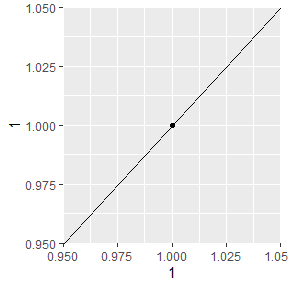

Example of the Line of Identity

```r
qplot(1,1) + geom_abline(intercept = 0, slope = 1)
```

In the following sections, let us see how well esophageal and rectal temperature are in agreement after exercising in the heat for 1 hour at differing conditions.

## Rectal Temperature

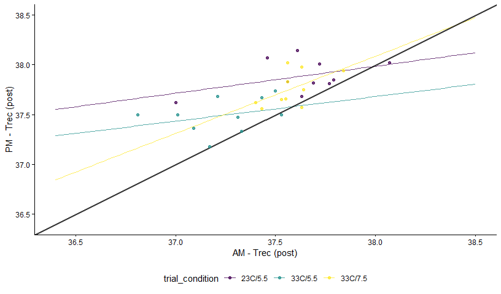

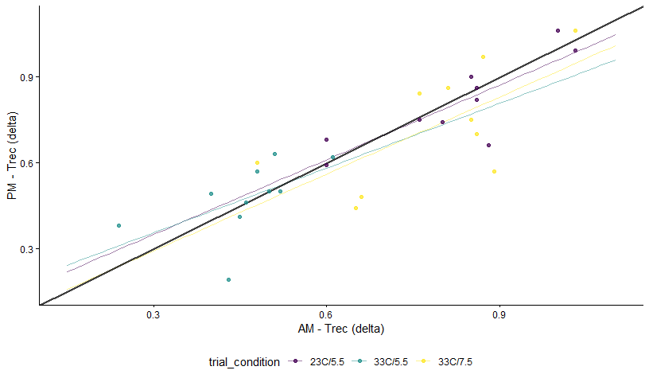

# Esophageal Temperature

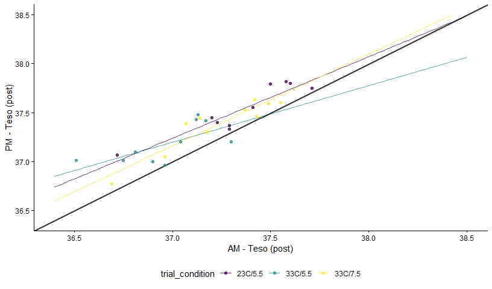

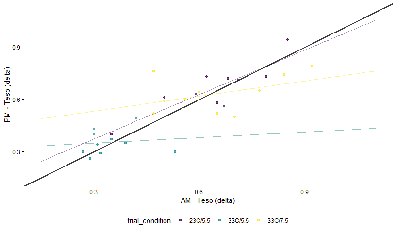

# Tolerance Limits to Assess Agreement

The `tolerance_limit` function can be used to calculate the “tolerance limits”. Typically a 95% prediction interval is calculated which provides the predicted difference between two measuring systems for 95% of future measurements pairs. However, we have to account for sampling error so we also need to estimate the confidence in the prediction intervals, and therefore we calculate the tolerance limits. So, when we have 95% tolerance limits for a 95% prediction interval, we can conclude that there is only a 5% probability (1-tolerance) that our tolerance limits do not contain the *true* prediction interval/limit.

## Rectal Temperature

```r
# note: more accurate tolerance limits are given by tol_method = "perc"
rec.post_tol = tolerance_limit(
  data = df_rec.post,
  x = "PM",
  y = "AM",
  id = "id",
  condition = "trial_condition"
)
```

```r
print(rec.post_tol)
```

```
#> Agreement between Measures (Difference: x-y)
#> 95% Prediction Interval with 95% Tolerance Limits
#>
#>  Condition  Bias          Bias CI Prediction Interval  Tolerance Limits
#>    23C/5.5 0.255 [0.0804, 0.4296]     [-0.324, 0.834] [-0.5232, 1.0332]
#>    33C/5.5 0.254 [0.0964, 0.4116]   [-0.3141, 0.8221] [-0.4971, 1.0051]
#>    33C/7.5 0.181   [0.021, 0.341]   [-0.7103, 1.0723] [-1.4736, 1.8356]
```

Furthermore, we can visualize the results with a Bland-Altman style plot of the tolerance. Notice, despite the tighter cluster in the 3rd condition, the prediction/tolerance limits are wider. This is a curious result, but if we inspect the results further (`rec.post_tol$emmeans`) we can see the degrees of freedom for this condition are horribly low.

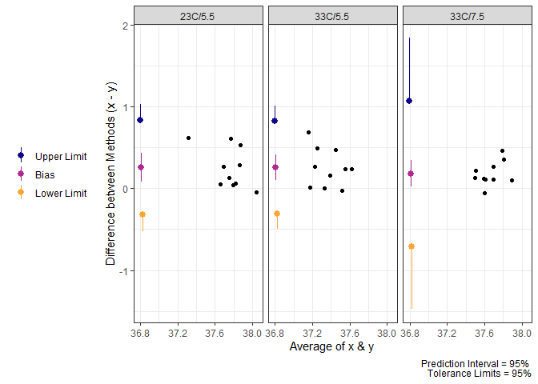

Tolerance Limits for Trec Post Exercise

```r
plot(rec.post_tol)
```

```r
rec.delta_tol = tolerance_limit(
  x = "PM",
  y = "AM",
  condition = "trial_condition",
  id = "id",
  data = df_rec.delta
)

rec.delta_tol
```

```
#> Agreement between Measures (Difference: x-y)
#> 95% Prediction Interval with 95% Tolerance Limits
#>
#>  Condition   Bias           Bias CI Prediction Interval  Tolerance Limits
#>    23C/5.5 -0.019   [-0.084, 0.046]   [-0.2345, 0.1965] [-0.3464, 0.3084]
#>    33C/5.5  0.015 [-0.0625, 0.0925]   [-0.1874, 0.2174] [-0.2645, 0.2945]
#>    33C/7.5 -0.059 [-0.1635, 0.0455]   [-0.2723, 0.1543] [-0.3516, 0.2336]
```

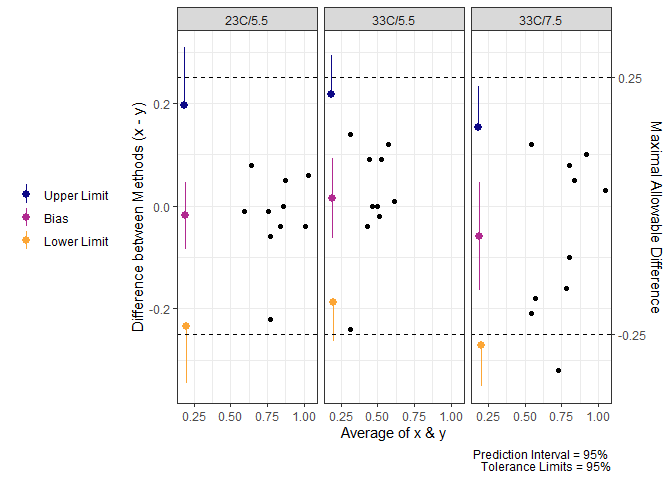

Tolerance Limits for Delta Trec

```r
# Plot Maximal Allowable Difference with delta argument
plot(rec.delta_tol,
     delta = .25)
```

## Esophageal Temperature

We can repeat the process for esophageal temperature. Overall, the results are fairly similar, and while there is better agreement on the delta (change scores), it is still fairly difficult to determine that there is “good” agreement between the AM and PM measurements.

```r
eso.post_tol = tolerance_limit(
  x = "AM",
  y = "PM",
  condition = "trial_condition",
  id = "id",
  data = df_eso.post
)

eso.delta_tol = tolerance_limit(
  x = "AM",
  y = "PM",
  condition = "trial_condition",
  id = "id",
  data = df_eso.delta
)
```

```r
eso.post_tol
```

```
#> Agreement between Measures (Difference: x-y)
#> 95% Prediction Interval with 95% Tolerance Limits
#>
#>  Condition   Bias            Bias CI Prediction Interval  Tolerance Limits
#>    23C/5.5 -0.180   [-0.256, -0.104]     [-0.432, 0.072] [-0.5526, 0.1926]
#>    33C/5.5 -0.212 [-0.3289, -0.0951]   [-0.4599, 0.0359] [-0.5402, 0.1162]
#>    33C/7.5 -0.146 [-0.2298, -0.0622]     [-0.415, 0.123] [-0.5651, 0.2731]
```

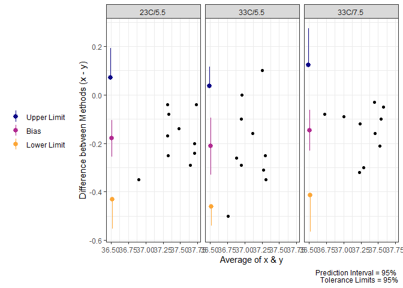

Limits of Agreement for Teso Post Exercise

```r
plot(eso.post_tol)
```

```r
eso.delta_tol
```

```
#> Agreement between Measures (Difference: x-y)
#> 95% Prediction Interval with 95% Tolerance Limits
#>
#>  Condition   Bias           Bias CI Prediction Interval  Tolerance Limits
#>    23C/5.5 -0.020 [-0.0747, 0.0347]   [-0.2013, 0.1613]   [-0.271, 0.231]
#>    33C/5.5 -0.005 [-0.0722, 0.0622]   [-0.1858, 0.1758] [-0.2459, 0.2359]
#>    33C/7.5  0.017 [-0.0849, 0.1189]   [-0.1827, 0.2167] [-0.2573, 0.2913]
```

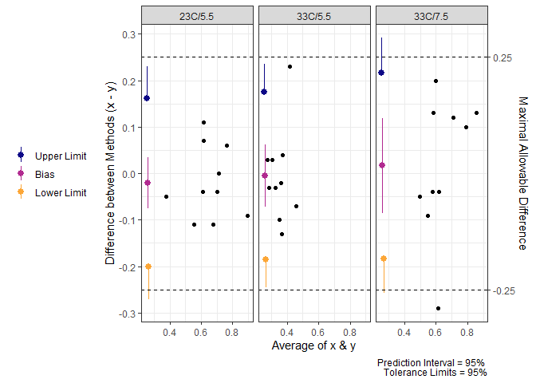

Limits of Agreement for Delta Teso

```r
plot(eso.delta_tol,
     delta = .25)
```

# References

Carrasco, Josep L., and Lluı́s Jover. 2003. “Estimating the Generalized Concordance Correlation Coefficient Through Variance Components.” *Biometrics* 59 (4): 849–58. https://doi.org/10.1111/j.0006-341x.2003.00099.x.

Carrasco, Josep L., Tonya S. King, and Vernon M. Chinchilli. 2009. “The Concordance Correlation Coefficient for Repeated Measures Estimated by Variance Components.” *Journal of Biopharmaceutical Statistics* 19 (1): 90–105. https://doi.org/10.1080/10543400802527890.

Carrasco, Josep Lluis, and Josep Puig Martinez. 2020. *Cccrm: Concordance Correlation Coefficient for Repeated (and Non-Repeated) Measures*. https://CRAN.R-project.org/package=cccrm.

Carrasco, Josep L., Brenda R. Phillips, Josep Puig-Martinez, Tonya S. King, and Vernon M. Chinchilli. 2013. “Estimation of the Concordance Correlation Coefficient for Repeated Measures Using SAS and r.” *Computer Methods and Programs in Biomedicine* 109 (3): 293–304. https://doi.org/10.1016/j.cmpb.2012.09.002.

Francq, Bernard G, Marion Berger, and Charles Boachie. 2020. “To Tolerate or to Agree: A Tutorial on Tolerance Intervals in Method Comparison Studies with BivRegBLS r Package.” *Statistics in Medicine* 39 (28): 4334–49.

Lin, Lawrence I-Kuei. 1989. “A Concordance Correlation Coefficient to Evaluate Reproducibility.” *Biometrics* 45 (1): 255. https://doi.org/10.2307/2532051.

Ravanelli, Nicholas, and Ollie Jay. 2020. “The Change in Core Temperature and Sweating Response During Exercise Are Unaffected by Time of Day Within the Wake Period.” *Medicine and Science in Sports and Exercise*. https://doi.org/10.1249/mss.0000000000002575.

[^1]: Josep Lluis Carrasco and Martinez (2020) is another package to check out